# Eksploracja Danych Tekstowych (Text Mining)

Mateusz Konieczny

# 1. Wstęp i Przygotowanie Danych

Celem mojego projektu była kompleksowa analiza ponad 23 tysięcy recenzji pochodzących ze sklepu odzieżowego (e-commerce). Aby móc wyciągnąć z tekstów użyteczne wnioski biznesowe, w pierwszej kolejności przygotowałem surowe dane, poddając je procesowi czyszczenia (NLP Preprocessing). Usunąłem interpunkcję, ujednoliciłem wielkość liter, stokenizowałem tekst oraz odfiltrowałem tzw. stop-words (słowa nieposiadające znaczenia analitycznego).

*Uwaga metodologiczna:* Świadomie zrezygnowałem z twardej stemizacji (odcinania końcówek słów). Zdecydowałem się na ten krok, ponieważ leksykony sentymentu, wykorzystywane w dalszych etapach pracy, wymagają pełnych, naturalnych form wyrazów do poprawnego przypisania im ładunku emocjonalnego.

```r
# Przygotowanie ramki danych z dodatkowymi zmiennymi (Wiek, Długość tekstu)
df_clean <- df %>%
  filter(!is.na(`Review Text`)) %>%
  mutate(text = paste(Title, `Review Text`, sep = " ")) %>%
  mutate(doc_id = row_number(),
         word_count = str_count(text, "\\w+")) %>%
  select(doc_id, text, Rating, Department = `Department Name`, Age, word_count)

# Tokenizacja i czyszczenie
tokens <- df_clean %>%
  mutate(text = str_replace_all(text, "[^a-zA-Z\\s]", " ")) %>%
  unnest_tokens(word, text) %>%
  anti_join(stop_words, by = "word") %>%
  filter(str_length(word) > 2)
```

# 2. Analiza Częstości (Wordcloud i TF-IDF)

Rozpocząłem od zbadania najczęściej pojawiających się słów w całym korpusie opinii. Chmura słów pozwala łatwo zorientować się w głównej tematyce. Następnie, aby wykluczyć pewne ogólniki, zastosowałem miarę **TF-IDF**, która redukuje znaczenie słów powszechnych, a uwypukla te, które są unikalne dla konkretnej kategorii ubrań (w tym wypadku działu “Sukienki”).

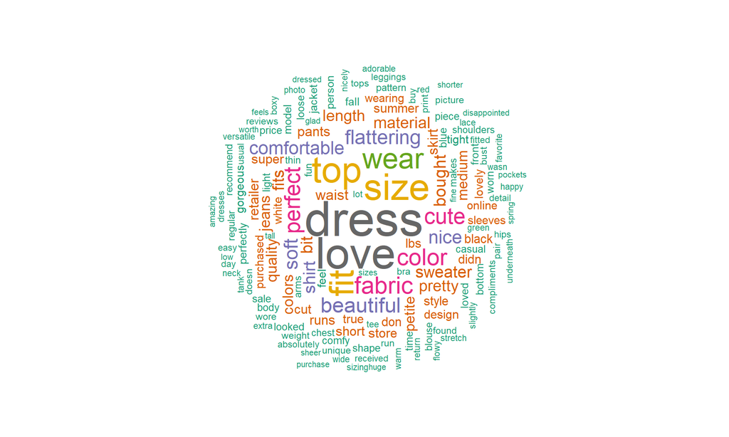

```r
# Chmura Słów (Wordcloud)
word_counts <- tokens %>% count(word, sort = TRUE)
set.seed(123)
wordcloud(words = word_counts$word, freq = word_counts$n, min.freq = 50,
          max.words = 150, random.order = FALSE, rot.per = 0.35,
          colors = brewer.pal(8, "Dark2"))
```

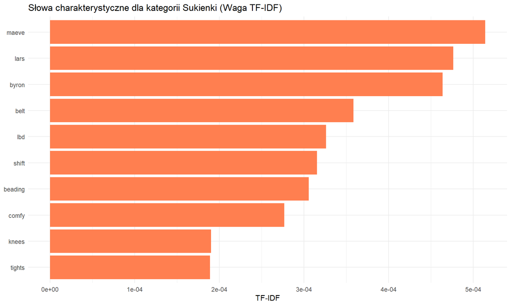

```r
# Analiza TF-IDF dla działu Sukienek
tfidf_words <- tokens %>%
  count(Department, word, sort = TRUE) %>%
  filter(!is.na(Department)) %>%
  bind_tf_idf(word, Department, n)

tfidf_words %>%
  filter(Department == "Dresses") %>%
  top_n(10, tf_idf) %>%
  ggplot(aes(reorder(word, tf_idf), tf_idf)) +
  geom_col(fill = "coral") +
  coord_flip() +
  labs(title = "Słowa charakterystyczne dla kategorii Sukienki (Waga TF-IDF)", x = NULL, y = "TF-IDF") +
  theme_minimal()
```

> **Wnioski z analizy częstości:** Chmura słów zarysowuje ogólny obraz dyskusji - dominują tu pojęcia takie jak *dress*, *size*, *fit* czy *love*. Zwykłe zliczanie wyrazów ma jednak swoje ograniczenia, ponieważ najpopularniejsze frazy często zamazują specyfikę poszczególnych produktów. Zastosowanie wagi TF-IDF dla kategorii “Sukienki” pozwoliło nam odfiltrować ten “szum” i wyłonić prawdziwe wyróżniki działu. Widzimy na nim specyficzne cechy fasonów, materiałów czy okazji, które precyzyjnie definiują tę kategorię na tle całego asortymentu sklepu.

# 3. Związki Frazeologiczne (N-gramy)

Analiza pojedynczych słów często pozbawia nas szerszego kontekstu. Z tego powodu sprawdziłem, jak słowa łączą się ze sobą w pary (bigramy). Wizualizacja w postaci grafu sieciowego pozwala dostrzec, że klientki często wyrażają się poprzez utarte związki frazeologiczne.

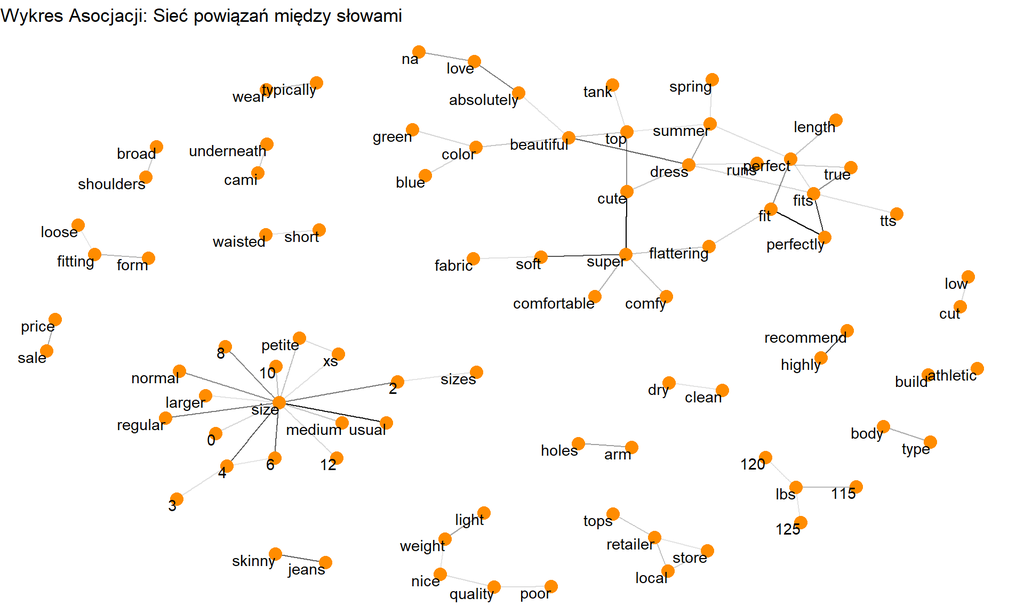

```r
bigrams <- df_clean %>%
  unnest_tokens(bigram, text, token = "ngrams", n = 2) %>%
  separate(bigram, c("word1", "word2"), sep = " ") %>%
  filter(!word1 %in% stop_words$word, !word2 %in% stop_words$word) %>%
  count(word1, word2, sort = TRUE) %>%
  filter(n > 100)

graph <- graph_from_data_frame(bigrams)
ggraph(graph, layout = "fr") +
  geom_edge_link(aes(edge_alpha = n), show.legend = FALSE, color = "black") +
  geom_node_point(color = "darkorange", size = 4) +
  geom_node_text(aes(label = name), vjust = 1, hjust = 1) +
  theme_void() +
  labs(title = "Wykres Asocjacji: Sieć powiązań między słowami")
```

# 4. Nienadzorowane Uczenie Maszynowe (Model LDA)

W kolejnym kroku zastosowałem algorytm nienadzorowanego uczenia maszynowego (Latent Dirichlet Allocation - LDA), którego zadaniem było zidentyfikowanie ukrytych struktur tematycznych w opiniach. Na wyniki działania algorytmu nałożyłem słownik sentymentu, co pozwoliło ocenić zabarwienie emocjonalne wydzielonych dyskusji.

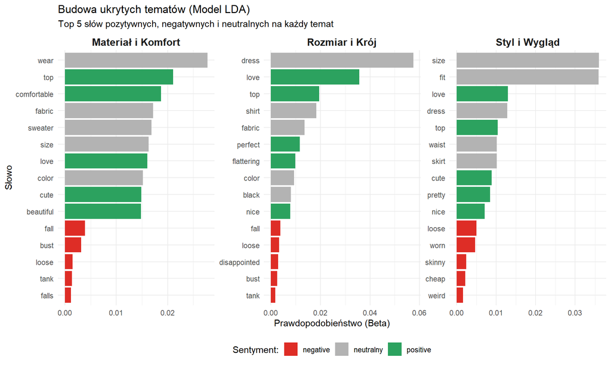

```r
set.seed(42)
sample_docs <- sample(df_clean$doc_id, 2000)

dtm <- tokens %>%
  filter(doc_id %in% sample_docs) %>%
  count(doc_id, word) %>%
  cast_dtm(doc_id, word, n)

lda_model <- LDA(dtm, k = 3, control = list(seed = 1234))
tematy <- tidy(lda_model, matrix = "beta")

tematy_z_sentymentem <- tematy %>%
  left_join(bing_lexicon, by = c("term" = "word"), relationship = "many-to-many") %>%
  mutate(sentiment = replace_na(sentiment, "neutralny")) %>%
  mutate(nazwa_kategorii = case_when(
    topic == 1 ~ "Rozmiar i Krój",
    topic == 2 ~ "Materiał i Komfort",
    topic == 3 ~ "Styl i Wygląd"
  )) %>%
  group_by(nazwa_kategorii, sentiment) %>%
  top_n(5, beta) %>%
  ungroup() %>%
  arrange(nazwa_kategorii, -beta)

tematy_z_sentymentem %>%
  ggplot(aes(reorder_within(term, beta, nazwa_kategorii), beta, fill = sentiment)) +
  geom_col() +
  facet_wrap(~ nazwa_kategorii, scales = "free") +
  coord_flip() +
  scale_x_reordered() +
  scale_fill_manual(values = c("positive" = "#2ca25f", "negative" = "#de2d26", "neutralny" = "gray70")) +
  labs(title = "Budowa ukrytych tematów (Model LDA)",
       subtitle = "Top 5 słów pozytywnych, negatywnych i neutralnych na każdy temat",
       x = "Słowo", y = "Prawdopodobieństwo (Beta)", fill = "Sentyment:") +
  theme_minimal() +
  theme(legend.position = "bottom", strip.text = element_text(size = 12, face = "bold"))
```

# 5. Klasyczna Analiza Sentymentu (Słownik Bing)

Aby zweryfikować poprawność matematycznej analizy NLP, zestawiłem wyliczony ładunek emocjonalny słów (słownik “Bing”) z rzeczywistą oceną gwiazdkową wystawioną przez kupujących.

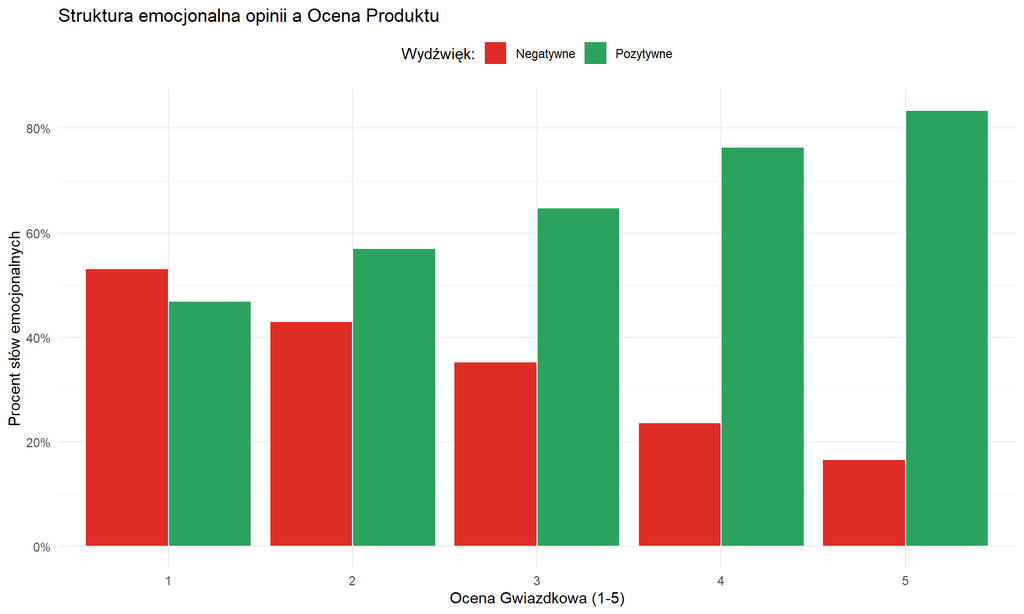

```r
sentiment_analysis_both <- tokens %>%
  inner_join(bing_lexicon, by = "word", relationship = "many-to-many") %>%
  count(Rating, sentiment) %>%
  spread(sentiment, n, fill = 0) %>%
  mutate(
    Pozytywne = positive / (positive + negative),
    Negatywne = negative / (positive + negative)
  ) %>%
  pivot_longer(cols = c(Pozytywne, Negatywne), names_to = "Typ_sentymentu", values_to = "Wskaznik")

ggplot(sentiment_analysis_both, aes(x = factor(Rating), y = Wskaznik, fill = Typ_sentymentu)) +
  geom_col(position = "dodge", color = "white") +
  scale_y_continuous(labels = scales::percent) +
  scale_fill_manual(values = c("Pozytywne" = "#2ca25f", "Negatywne" = "#de2d26")) +
  labs(title = "Struktura emocjonalna opinii a Ocena Produktu",
       x = "Ocena Gwiazdkowa (1-5)", y = "Procent słów emocjonalnych", fill = "Wydźwięk:") +
  theme_minimal() +
  theme(legend.position = "top")
```

# 6. Profil Emocjonalny NRC (Wykres Piramidowy)

Aby pogłębić badanie emocji poza standardowy podział na opinie pozytywne i negatywne, wykorzystałem słownik NRC, który kategoryzuje słowa w 8 wymiarach ludzkich emocji. Wykres piramidowy pozwala bezpośrednio zestawić skrajne oceny i sprawdzić, co dokładnie charakteryzuje najbardziej zadowolonych i niezadowolonych klientów.

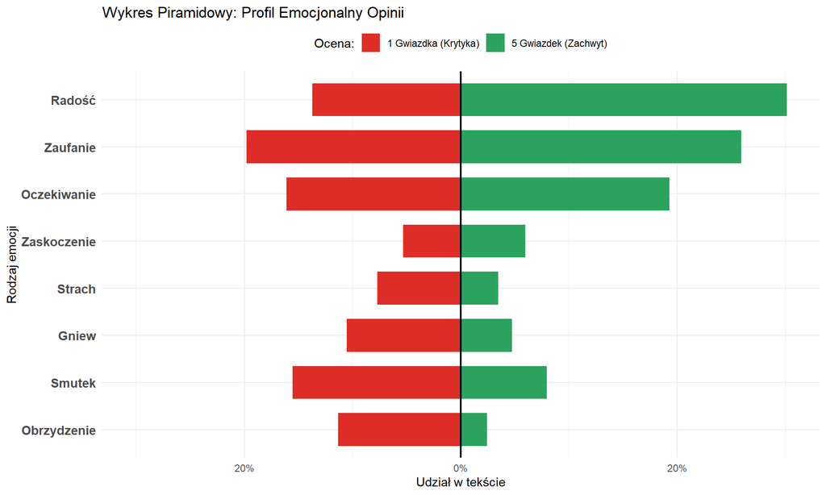

```r
emotion_profile <- tokens %>%
  inner_join(nrc_lexicon, by = "word", relationship = "many-to-many") %>%
  filter(Rating %in% c(1, 5)) %>%
  count(Rating, sentiment) %>%
  mutate(sentiment_pl = case_when(
    sentiment == "anger" ~ "Gniew", sentiment == "anticipation" ~ "Oczekiwanie",
    sentiment == "disgust" ~ "Obrzydzenie", sentiment == "fear" ~ "Strach",
    sentiment == "joy" ~ "Radość", sentiment == "sadness" ~ "Smutek",
    sentiment == "surprise" ~ "Zaskoczenie", sentiment == "trust" ~ "Zaufanie",
    TRUE ~ sentiment
  )) %>%
  group_by(Rating) %>%
  mutate(proporcja = n / sum(n)) %>%
  ungroup() %>%
  mutate(proporcja_wykres = ifelse(Rating == 1, -proporcja, proporcja))

ggplot(emotion_profile, aes(x = reorder(sentiment_pl, proporcja_wykres), y = proporcja_wykres, fill = factor(Rating))) +
  geom_col(width = 0.7) +
  coord_flip() +
  geom_hline(yintercept = 0, color = "black", linewidth = 0.8) +
  scale_fill_manual(values = c("1" = "#de2d26", "5" = "#2ca25f"),
                    labels = c("1 Gwiazdka (Krytyka)", "5 Gwiazdek (Zachwyt)")) +
  scale_y_continuous(labels = function(x) scales::percent(abs(x)),
                     limits = c(-max(abs(emotion_profile$proporcja_wykres)), max(abs(emotion_profile$proporcja_wykres)))) +
  labs(title = "Wykres Piramidowy: Profil Emocjonalny Opinii",
       x = "Rodzaj emocji", y = "Udział w tekście", fill = "Ocena:") +
  theme_minimal() +
  theme(legend.position = "top", axis.text.y = element_text(face = "bold", size = 11))
```

# 7. Demografia i Behawiorystyka

W ostatniej części projektu poszerzyłem analizę tekstową o dane behawioralne i demograficzne. Zbadałem zależność pomiędzy wiekiem klientek a sentymentem ich wypowiedzi, a także zweryfikowałem, przy jakich ocenach klienci wykazują największą tendencję do tworzenia długich opinii.

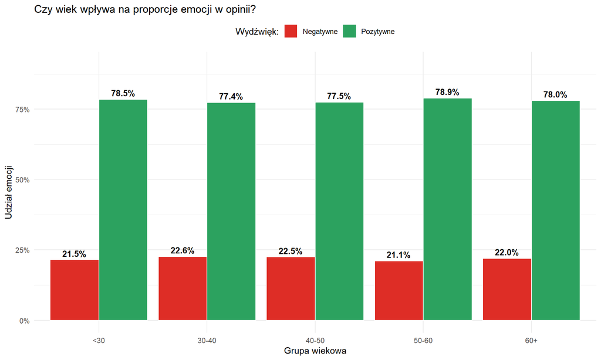

```r
# 7.1 Wiek vs Sentyment
age_sentiment <- tokens %>%
  inner_join(bing_lexicon, by = "word", relationship = "many-to-many") %>%
  count(doc_id, Age, sentiment) %>%
  spread(sentiment, n, fill = 0) %>%
  mutate(
    Age_Group = cut(Age, breaks = c(0, 30, 40, 50, 60, 100), labels = c("<30", "30-40", "40-50", "50-60", "60+")),
    Suma_emocji = positive + negative,
    Pozytywne = positive / Suma_emocji,
    Negatywne = negative / Suma_emocji
  ) %>%
  filter(Suma_emocji > 0) %>%
  group_by(Age_Group) %>%
  summarise(Pozytywne = mean(Pozytywne, na.rm = TRUE), Negatywne = mean(Negatywne, na.rm = TRUE)) %>%
  pivot_longer(cols = c(Pozytywne, Negatywne), names_to = "Typ_sentymentu", values_to = "Wskaznik")

ggplot(age_sentiment, aes(x = Age_Group, y = Wskaznik, fill = Typ_sentymentu)) +
  geom_col(position = "dodge", color = "white") +
  geom_text(aes(label = scales::percent(Wskaznik, accuracy = 0.1)), position = position_dodge(width = 0.9), vjust = -0.5, size = 3.5, fontface = "bold") +
  scale_fill_manual(values = c("Pozytywne" = "#2ca25f", "Negatywne" = "#de2d26")) +
  scale_y_continuous(labels = scales::percent, limits = c(0, max(age_sentiment$Wskaznik) * 1.15)) +
  labs(title = "Czy wiek wpływa na proporcje emocji w opinii?", x = "Grupa wiekowa", y = "Udział emocji", fill = "Wydźwięk:") +
  theme_minimal() + theme(legend.position = "top")
```

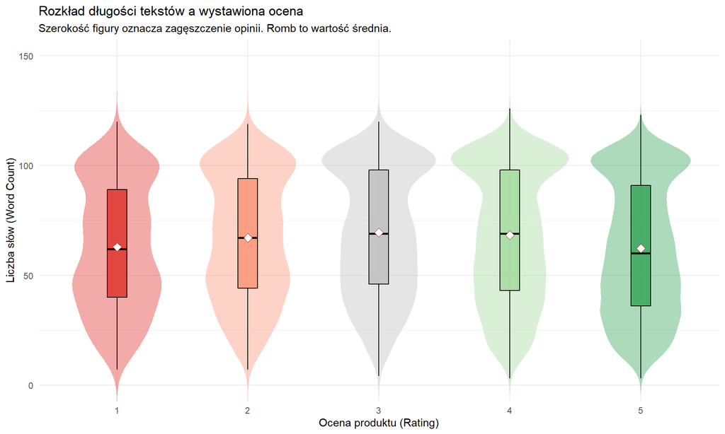

```r
# 7.2 Rozkład długości opinii (Wykres skrzypcowy)
ggplot(df_clean, aes(x = factor(Rating), y = word_count, fill = factor(Rating))) +
  geom_violin(alpha = 0.4, color = NA, trim = FALSE) +
  geom_boxplot(width = 0.15, alpha = 0.8, outlier.shape = NA, color = "black") +
  stat_summary(fun = mean, geom = "point", shape = 23, size = 3, fill = "white", color = "darkred") +
  scale_fill_manual(values = c("#de2d26", "#fc9272", "#bdbdbd", "#a1d99b", "#31a354")) +
  coord_cartesian(ylim = c(0, 150)) +
  labs(title = 'Rozkład długości tekstów a wystawiona ocena',
       subtitle = "Szerokość figury oznacza zagęszczenie opinii. Romb to wartość średnia.",
       x = "Ocena produktu (Rating)", y = "Liczba słów (Word Count)") +
  theme_minimal() + theme(legend.position = "none")
```

> **Wnioski z analizy demograficznej i długości tekstu:** 1. **Analiza sentymentu względem wieku:** Zestawienie pokazuje, że poziom pozytywnych emocji w opiniach pozostaje wysoce optymistyczny i w zasadzie stały, niezależnie od tego, do jakiej grupy wiekowej należy klientka. Różnice między poszczególnymi pokoleniami są statystycznie minimalne (rzędu 1-2 punktów procentowych). Oznacza to, że badana marka zapewnia spójne i pozytywne doświadczenie zakupowe dla wszystkich segmentów demograficznych. 2. **Analiza długości tekstu (Wykres skrzypcowy):** Analizując obszerność recenzji, możemy zauważyć interesującą tendencję. Najkrótsze opinie towarzyszą skrajnym ocenom (1 i 5 gwiazdek), gdzie przeważają jednoznaczne i zwięzłe komunikaty pełnego zachwytu lub odrzucenia produktu. Z kolei najdłuższe teksty i najgrubsze rozkłady przypisane są ocenom pośrednim (w szczególności 3 i 4 gwiazdkom). Wynika to z faktu, że oceny “przeciętne” wymagają od klientek większego zniuansowania i argumentacji - dokładnego opisu zbalansowanych wad oraz zalet produktu, co w naturalny sposób prowadzi do tworzenia bardziej rozbudowanych opinii. W przypadku ocen skrajnych, emocje są na tyle silne, że klientki nie czują potrzeby rozwijania swoich wypowiedzi, ograniczając się do krótkich, ale treściwych komunikatów.